# NBA Attendance

AJ Eckmann

3/1/2021

## EDA

The dataset contains 10,000 rows and 8 columns. The dataset is designed to be attendance totals for NBA basketball games. The response variable is attendance, which is the number of fans that attended the basketball game on that day. The other columns are:

Weekday; categorical variable of the day of the game

Time; categorical variable of the time of the game

conf; categorical variable signifying non-conference, conference or rivalry game

opp_win_p; categorical variable of win percentage of the away team

opp_all_stars; variable of number of players on away team that are all stars

win_p; continuous variable between 0 and 1 of the home team winning percentage at the time of the game

Below are histograms and bar charts of the distributions of these variables in the dataset, as well as summary stats of the continuous variables.

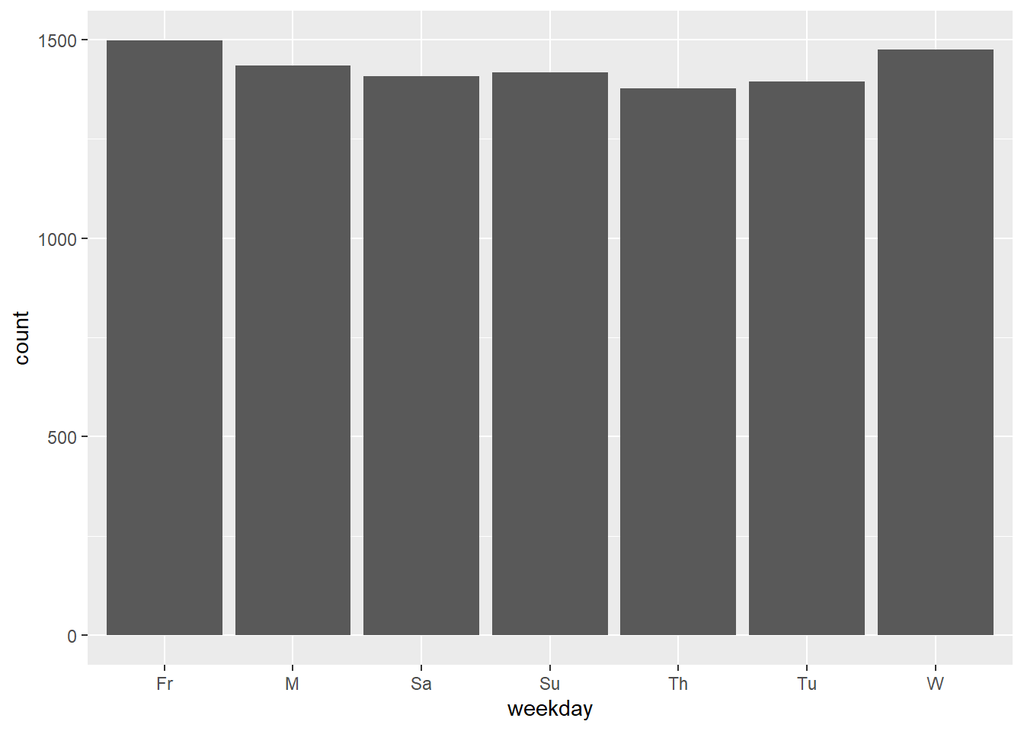

```r
ggplot(data = dat) +
  geom_bar(mapping = aes(x = weekday))
```

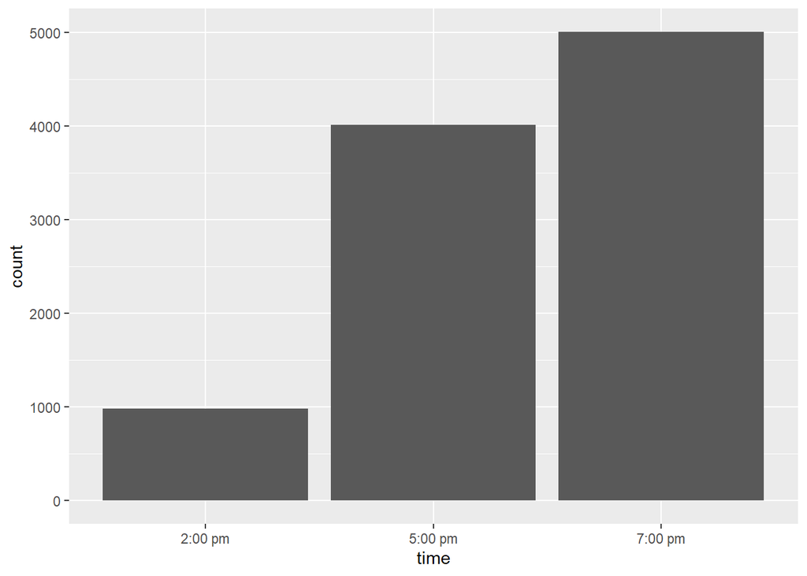

```r
ggplot(data = dat) +
  geom_bar(mapping = aes(x = time))
```

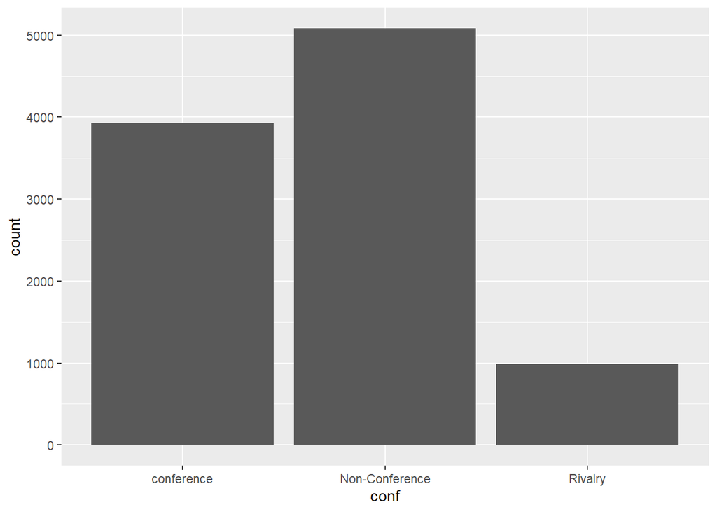

```r
ggplot(data = dat) +
  geom_bar(mapping = aes(x = conf))
```

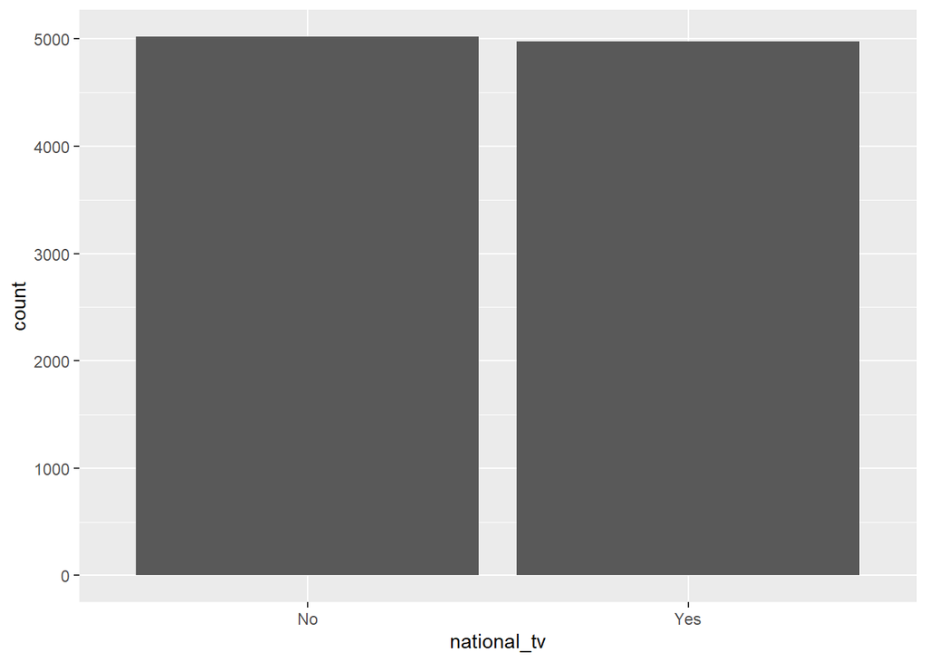

```r
ggplot(data = dat) +
  geom_bar(mapping = aes(x = national_tv))
```

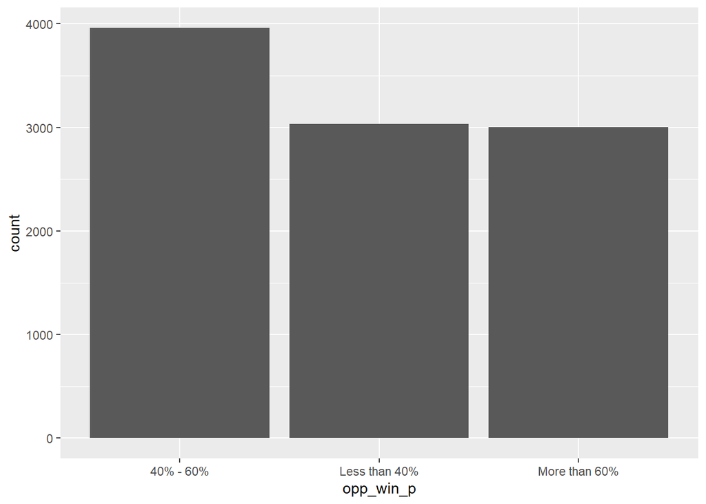

```r
ggplot(data = dat) +
  geom_bar(mapping = aes(x = opp_win_p))
```

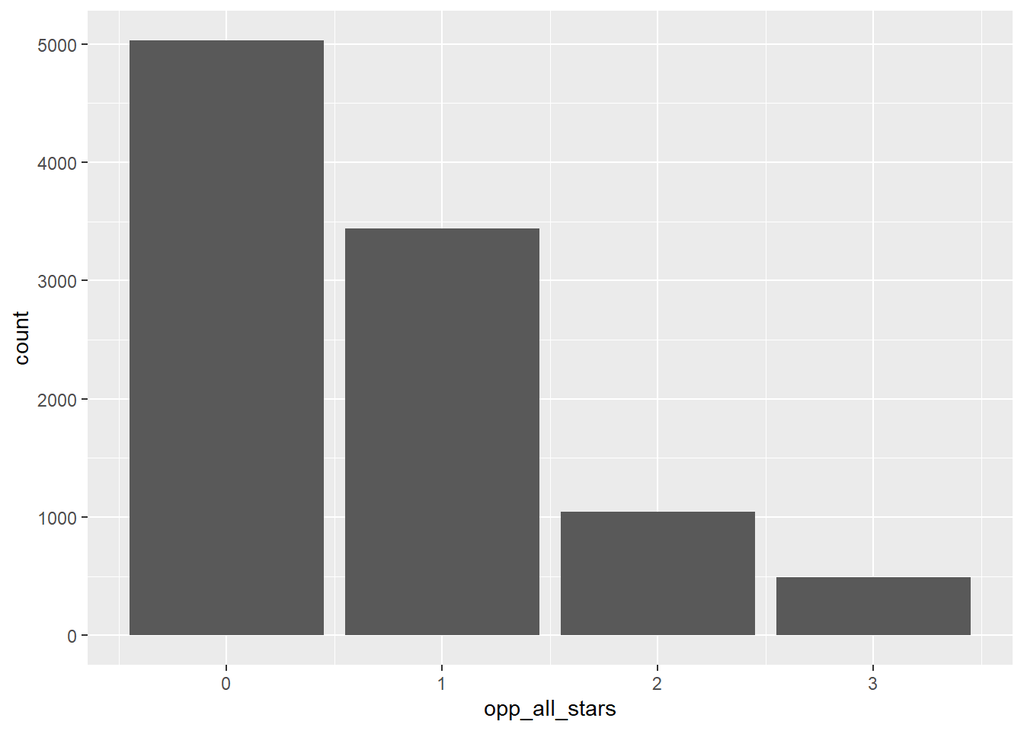

```r
ggplot(data = dat) +
  geom_bar(mapping = aes(x = opp_all_stars))
```

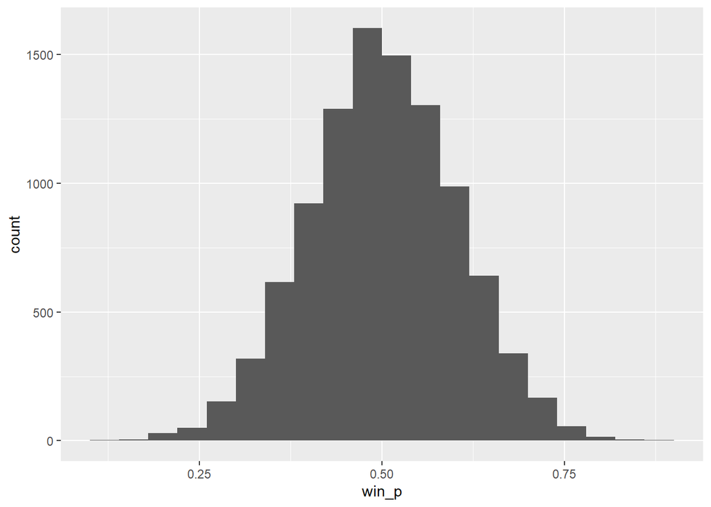

```r
ggplot(data = dat) +
  geom_histogram(mapping = aes(x = win_p), binwidth = 0.04)
```

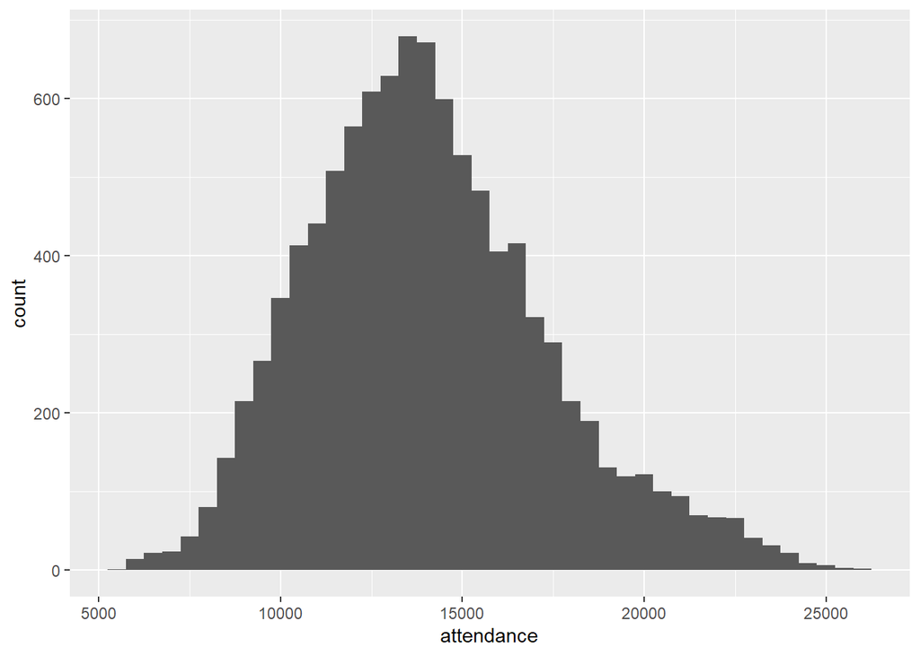

```r
ggplot(data = dat) +
  geom_histogram(mapping = aes(x = attendance), binwidth = 500)
```

```r
summary(dat$win_p)
```

```
##    Min. 1st Qu.  Median    Mean 3rd Qu.    Max.
##  0.1321  0.4338  0.5004  0.5016  0.5703  0.8966
```

```r
summary(dat$attendance)
```

```
##    Min. 1st Qu.  Median    Mean 3rd Qu.    Max.
##    5326   11734   13752   14049   16028   25837
```

Lastly, I have attached some frequency and box plots to help visualize the impacts of these variables on the attendance response variable.

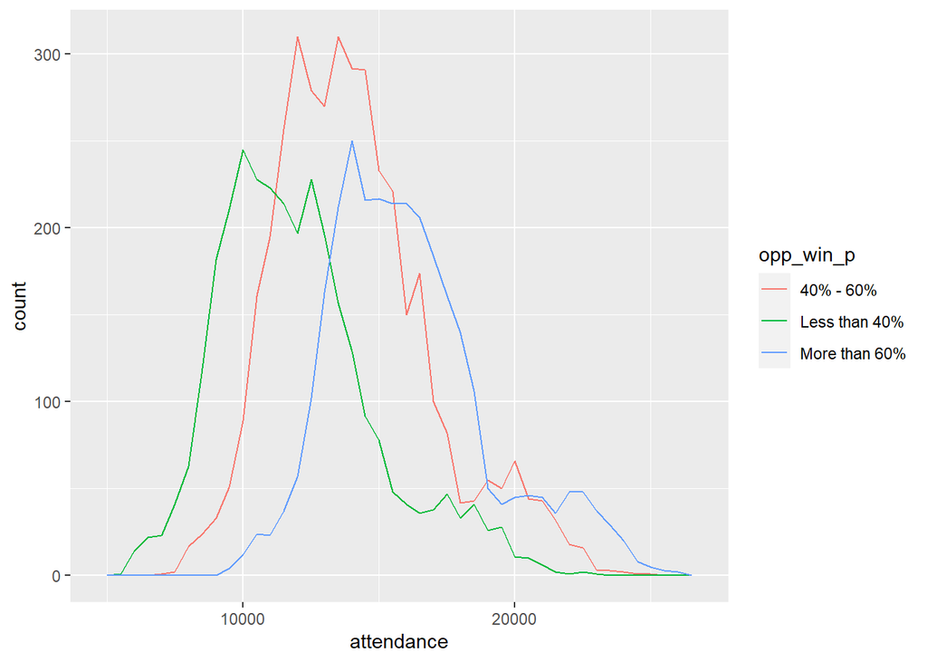

```r
ggplot(data = dat, mapping = aes(x = attendance, colour = opp_win_p)) +
  geom_freqpoly(binwidth = 500)
```

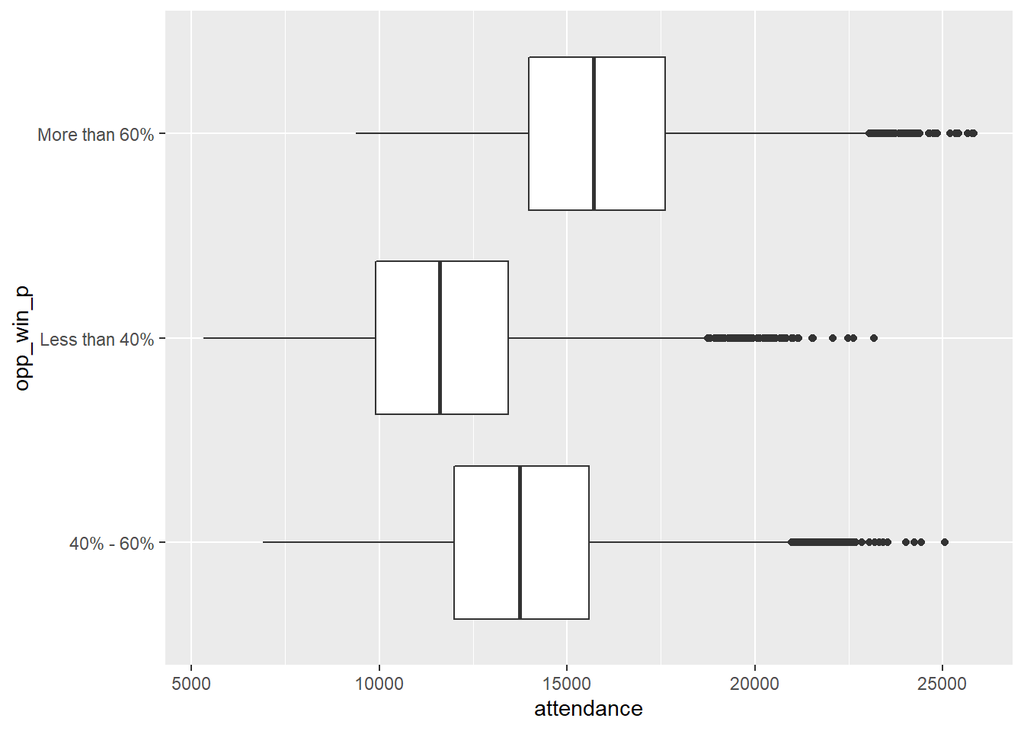

```r
ggplot(data = dat, mapping = aes(x = attendance, y = opp_win_p)) +
  geom_boxplot()
```

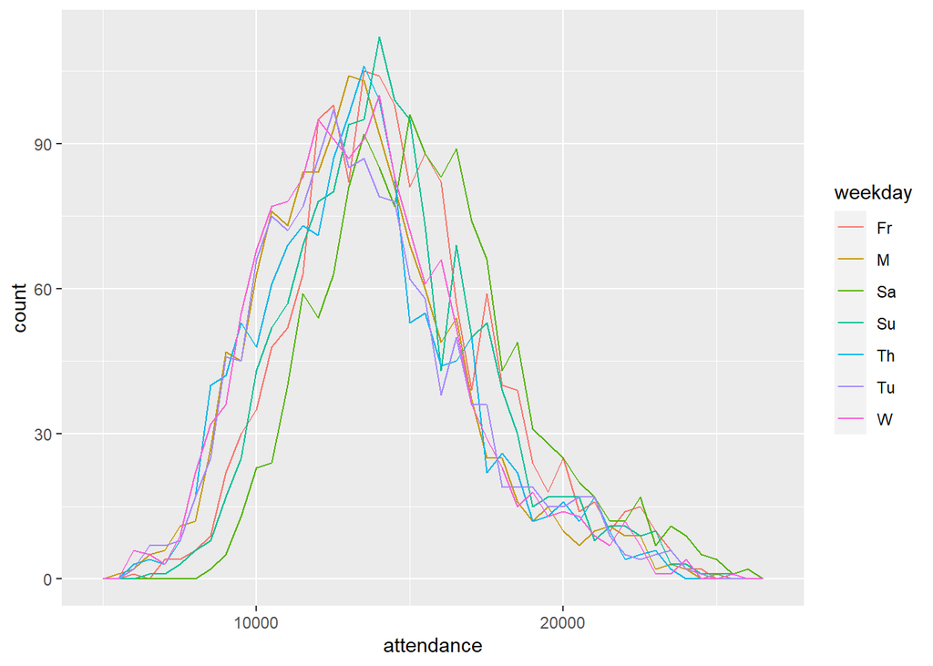

```r
ggplot(data = dat, mapping = aes(x = attendance, colour = weekday)) +
  geom_freqpoly(binwidth = 500)
```

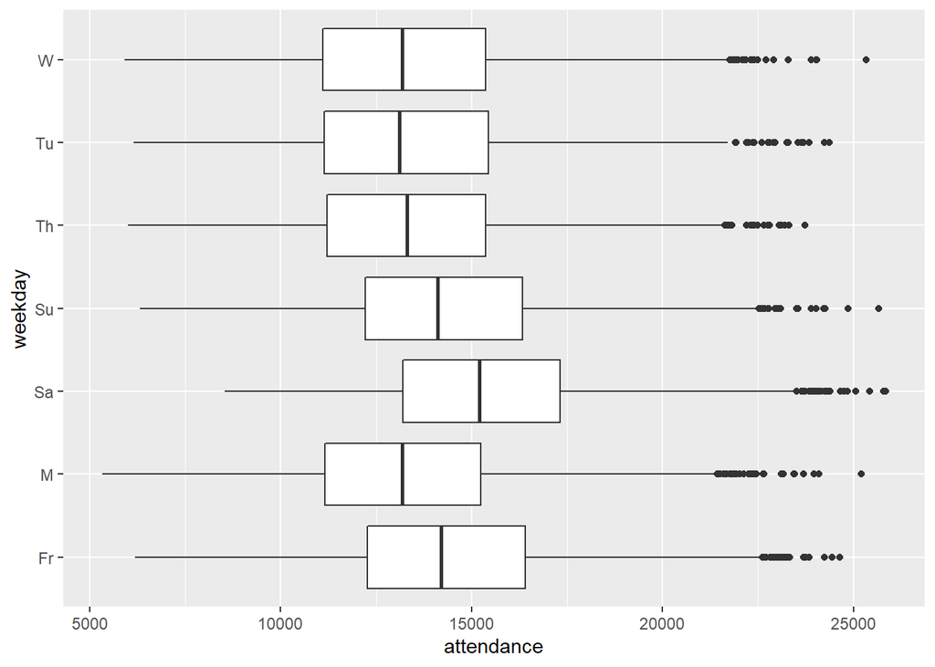

```r
ggplot(data = dat, mapping = aes(x = attendance, y = weekday)) +
  geom_boxplot()
```

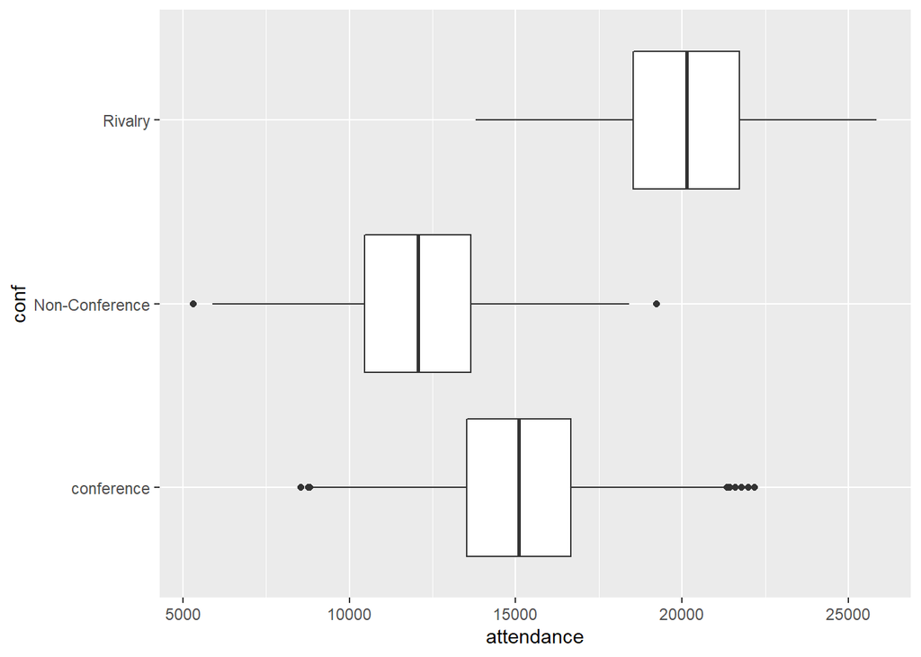

```r
ggplot(data = dat, mapping = aes(x = attendance, y = conf)) +
  geom_boxplot()
```